# TP Times series - Mardoché Clabessi

```r
# Charger les bibliothèques nécessaires
library(stats)
```

# $\textbf{Contextualisation}$

Les objectifs du TP ont été :

1. L’appréhension de la différence entre les probabilités et la statistique dans l’étude des séries chronologiques.
2. L’analyse des comportements des fonctions d’autocorrélation et d’autocorrélation partielle pour les processus AR, MA et ARMA.

# $\textbf{1. Introduction au logiciel R}$

Cette section a été dédiée à l’acquisition de notions introductives sur le langage R et son utilisation. Elle a couverte notamment les structures de données en R, l’importation de données depuis un fichier externe, l’utilisation des boucles, la création de graphiques, ainsi que l’écriture de fonctions en R.

# $\textbf{2. Analyse de séries temporelles avec R}$

$\textbf{2.1 Processus non-stationnaire}$

Le but de l’exercice est de simuler le processus

$$X_t = X_{t-1} + \varepsilon_t, \quad t
\in \mathbb{N}, \quad X_0 = 0.$$

Le processus $\{\varepsilon_t, t \in \mathbb{N}\}$ est un bruit blanc gaussien de variance $\sigma^2 = 1$.

#### 1. Simulons sur R le processus $X_t$ pour $t = 1, \ldots, n$ avec $n = 200$.

```r
# Paramètres
n <- 200
sigma <- 1

# Initialisation du processus
Xt <- numeric(n)
Xt[1] <- 0  # X0 = 0

# Simulation du processus
set.seed(123)  # Pour la reproductibilité
epsilon <- rnorm(n, mean = 0, sd = sigma)

for (t in 2:n) {
  Xt[t] <- Xt[t - 1] + epsilon[t]
}
```

#### 2. Traçons le processus $X_t$ en fonction du temps.

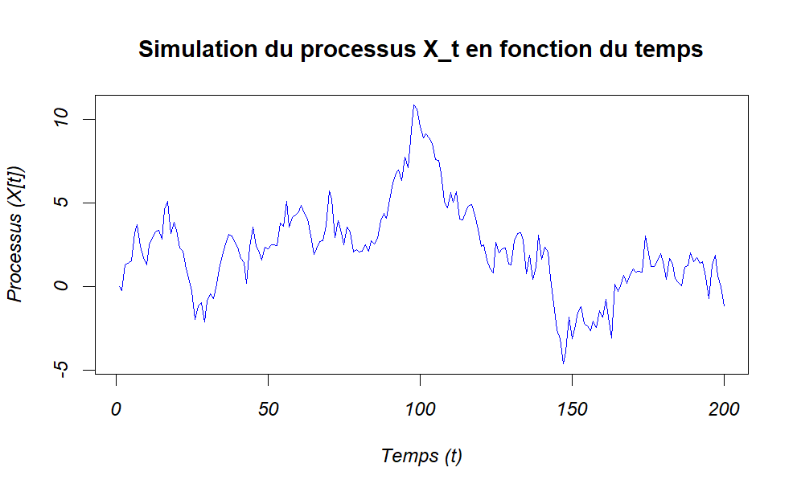

```r
# Tracé du processus en fonction du temps
plot(Xt, type = "l", col = "blue", xlab = "Temps (t)", ylab = "Processus (X[t])", main = "Simulation du processus X_t en fonction du temps")
```

##### Explication du comportement non-stationnaire

On remarque sur le graphique que la courbe reste beaucoup en dessous ou au dessous de $X_0$ et souvent le temps de retour en $X_0$ est bien grand, ce qui suggère que la moyenne de $X_t$ n’est pas constante avec le temps; ce qui est un comportement non stationnaire.

#### 3. Traçons la fonction d’autocorrélation

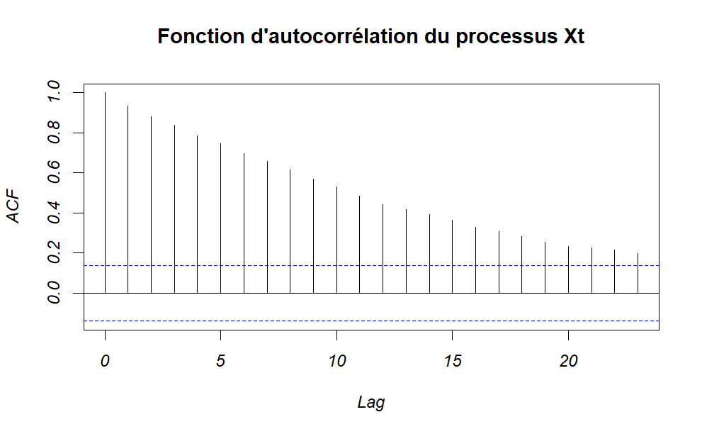

```r
# Tracé de la fonction d'autocorrélation
acf(Xt, main = "Fonction d'autocorrélation du processus Xt")
```

##### Constat sur le comportement de la fonction d’autocorrélation

La fonction d’autocorrélation montre une décroissance lente, indiquant que les valeurs de $X_t$ sont fortement corrélées avec leurs valeurs passées, ce qui est typique d’un processus non-stationnaire comme une marche aléatoire.

# $\textbf{2.2 Processus MA(q)}$

Nous souhaitons illustrer le comportement des fonctions d’autocorrélation et d’autocorrélation partielle pour les processus MA(q).

Nous allons d’abord simuler un processus MA(1) :

$$X_t = \varepsilon_t + \theta \varepsilon_{t-1}, \quad t \in \mathbb{N^*}$$

#### 1) On choisit $\theta = 0.9$.

##### Inversibilité du processus

Le polynôme caractéristique du processus $MA(1)$ est donné par :

$$1 + \theta z = 0$$

La racine de cette équation est :

$$z = -\frac{1}{\theta}$$

Pour que le processus soit inversible, il faut que la valeur absolue de cette racine soit supérieure à 1, c’est-à-dire :

$$\left| -\frac{1}{\theta} \right| > 1$$

Cela revient à :

$$|\theta| < 1$$

Dans notre cas, avec $\theta = 0.9$ :

$$|\theta| = 0.9 < 1$$

Ainsi, le processus MA(1) avec $\theta = 0.9$ **est inversible**.

##### Simuler le processus $X_t$ pour $t = 1, \ldots, n$, avec $n = 1000$.

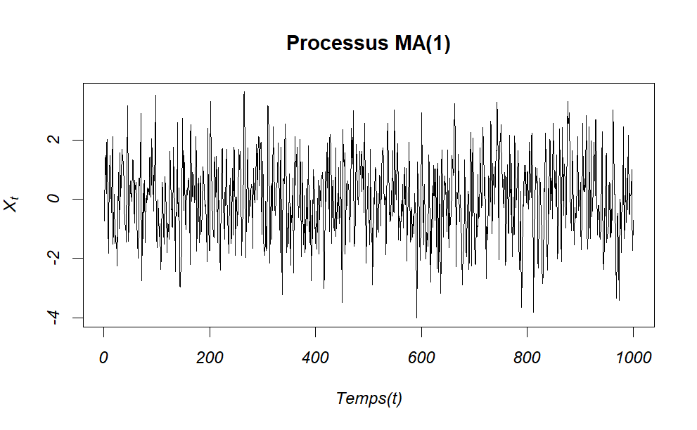

```r
# Paramètres
theta <- 0.9  # Coefficient MA(1)
n <- 1000     # Nombre d'observations

# Simuler un processus MA(1)
set.seed(123)  # Pour la reproductibilité
epsilon <- rnorm(n, mean = 0, sd = 1)  # Erreurs blanches

# Initialiser le vecteur Xt
Xt <- numeric(n)
# Boucle pour simuler le processus MA(1)
for (t in 1:n) {
  if (t == 1) {
    Xt[t] <- epsilon[t]  # Pour t = 1, pas d'ε_{t-1}
  } else {
    Xt[t] <- epsilon[t] + theta * epsilon[t - 1]  # Ajout de ε_t et θ * ε_{t-1}
  }
}

# Tracer le processus simulé
ts.plot(Xt, main = "Processus MA(1)", ylab = expression(X[t]), xlab = "Temps(t)", col='black', type='l')
```

##### Traçons les fonctions d’autocorrélation et d’autocorrélation partielle.

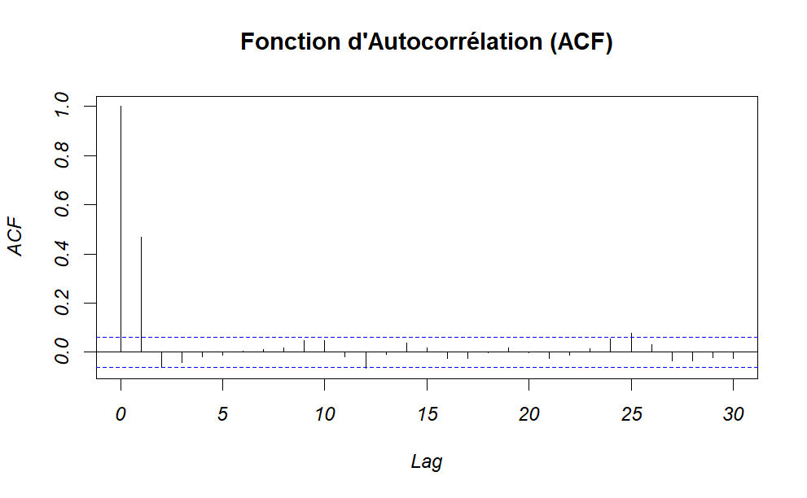

```r
# Tracer la fonction d'autocorrélation (ACF)
acf(Xt, main = "Fonction d'Autocorrélation (ACF)")
```

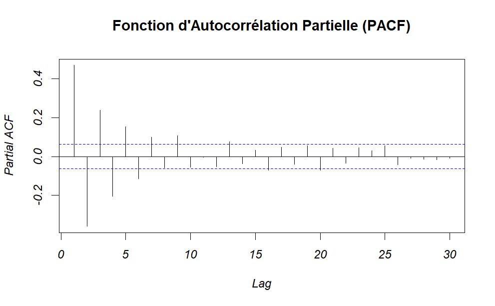

```r
# Tracer la fonction d'autocorrélation partielle (PACF)
pacf(Xt, main = "Fonction d'Autocorrélation Partielle (PACF)")
```

#### 2) Analyse du processus MA(1) avec $\theta = -0.9$

##### Inversibilité

D’après la démonstration faite en question 1), le processus MA(1) est inversible si le paramètre $\theta$ est tel que $|\theta| < 1$. Dans ce cas, comme $\theta = -0.9$, nous avons $|-0.9| = 0.9 < 1$. Par conséquent, le processus est inversible.

##### Simulation du processus MA(1) avec $\theta = -0.9$

```r
# Paramètres
theta <- -0.9  # Coefficient MA(1)
n <- 1000      # Nombre d'observations

# Simuler un processus MA(1)
set.seed(1)  # Pour la reproductibilité
epsilon <- rnorm(n, mean = 0, sd = 1)  # Erreurs blanches

# Initialiser le vecteur Xt
Xt <- numeric(n)

# Boucle pour simuler le processus MA(1)
for (t in 1:n) {
  if (t == 1) {
    Xt[t] <- epsilon[t]  # Pour t = 1, pas d'ε_{t-1}
  } else {
    Xt[t] <- epsilon[t] + theta * epsilon[t - 1]  # Ajout de ε_t et θ * ε_{t-1}
  }
}
```

##### Traçons le processus $X_t$ en fonction du temps

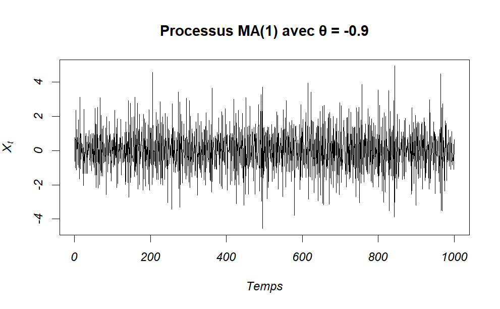

```r
# Tracer le processus simulé
ts.plot(Xt, main = "Processus MA(1) avec θ = -0.9", ylab = expression(X[t]), xlab = "Temps")
```

#### Traçons les fonctions d’autocorrélation et d’autocorrélation partielle.

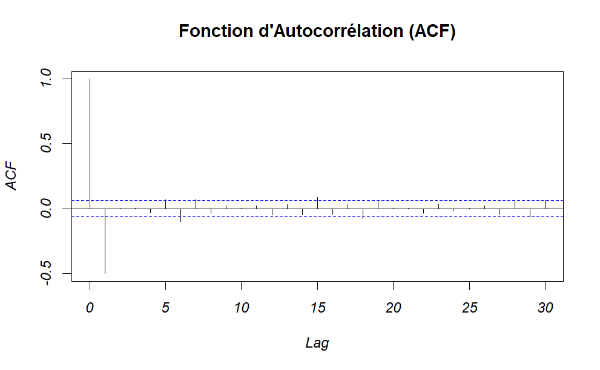

```r
# Tracer la fonction d'autocorrélation (ACF)
acf(Xt, main = "Fonction d'Autocorrélation (ACF)")
```

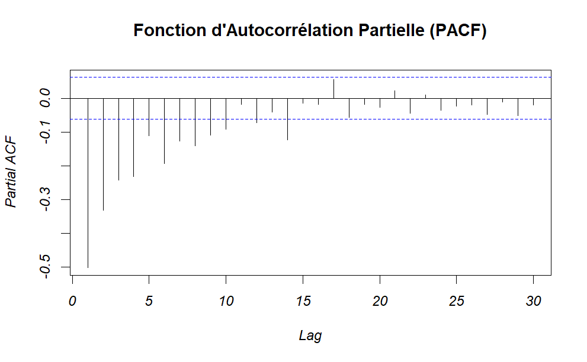

```r
# Tracer la fonction d'autocorrélation partielle (PACF)
pacf(Xt, main = "Fonction d'Autocorrélation Partielle (PACF)")
```

#### Simulation d’un processus MA(2)

Nous allons maintenant simuler un processus MA(2) défini par :

$$X_t = \varepsilon_t + \theta_1 \varepsilon_{t-1} + \theta_2
\varepsilon_{t-2}, \quad t \in \mathbb{N^*}$$

#### 3) Choix des paramètres

Nous choisissons $\theta_1 = 0.3$ et $\theta_2 = -0.4$.

### Inversibilité

Pour qu’un processus MA(2) soit inversible, nous devons examiner les racines du polynôme caractéristique associé, qui est :

$$1 + \theta_1 z + \theta_2 z^2 = 0$$

Un processus MA(2) est inversible si les racines de ce polynôme sont à l’extérieur du cercle unité dans le plan complexe, c’est-à-dire si leurs modules sont supérieurs à 1.

Avec $\theta_1 = 0.3$ et $\theta_2 = -0.4$, le polynôme caractéristique devient :

$$1 + 0.3z - 0.4z^2 = 0$$

En résolvant cette équation quadratique, nous trouvons les racines suivantes :

##### Simulation du processus MA(2) avec $(\theta_1 = 0.3) ~~ et~~ (\theta_2 = -0.4)$

```r
# Paramètres
theta1 <- 0.3  # Coefficient MA(1)
theta2 <- -0.4  # Coefficient MA(2)
n <- 1000       # Nombre d'observations

# Simuler un processus MA(2)
set.seed(123)  # Pour la reproductibilité
epsilon <- rnorm(n, mean = 0, sd = 1)  # Erreurs blanches

# Initialiser le vecteur Xt
Xt <- numeric(n)

# Boucle pour simuler le processus MA(2)
for (t in 1:n) {
  if (t == 1) {
    Xt[t] <- epsilon[t]  # Pour t = 1, pas de ε_{t-1} ni ε_{t-2}
  } else if (t == 2) {
    Xt[t] <- epsilon[t] + theta1 * epsilon[t - 1]  # Pour t = 2, pas de ε_{t-2}
  } else {
    Xt[t] <- epsilon[t] + theta1 * epsilon[t - 1] + theta2 * epsilon[t - 2]  # MA(2) complet
  }
}
```

##### Traçons le processus $X_t$ en fonction du temps

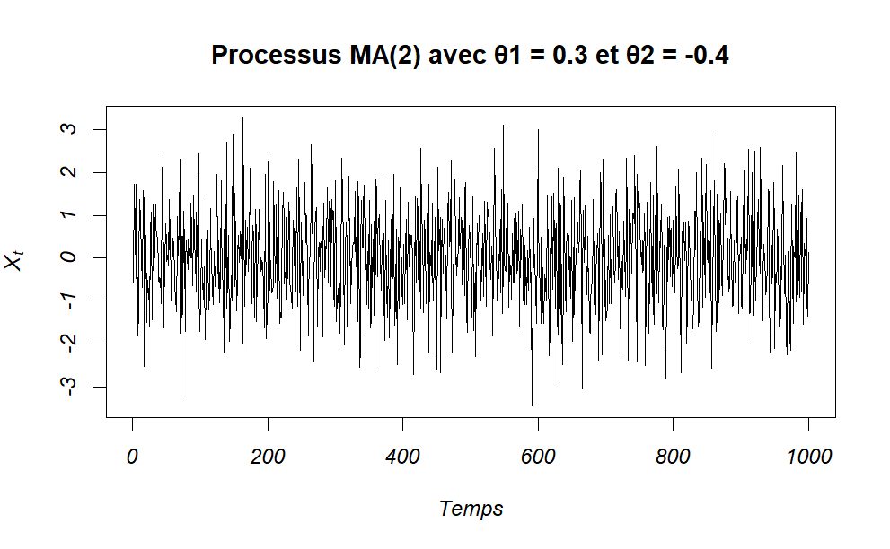

```r
# Tracer le processus simulé
ts.plot(Xt, main = "Processus MA(2) avec θ1 = 0.3 et θ2 = -0.4", ylab = expression(X[t]), xlab = "Temps")
```

#### Traçons les fonctions d’autocorrélation et d’autocorrélation partielle.

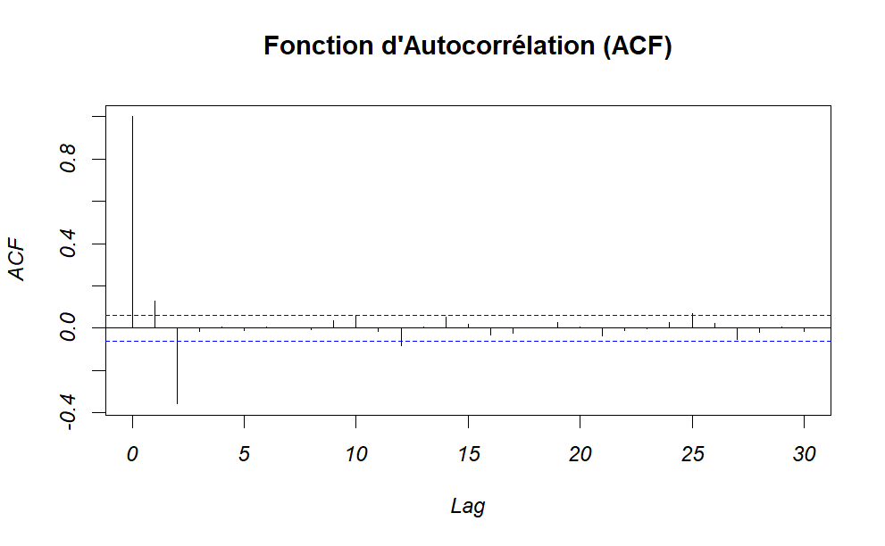

```r
# Tracer la fonction d'autocorrélation (ACF)
acf(Xt, main = "Fonction d'Autocorrélation (ACF)")
```

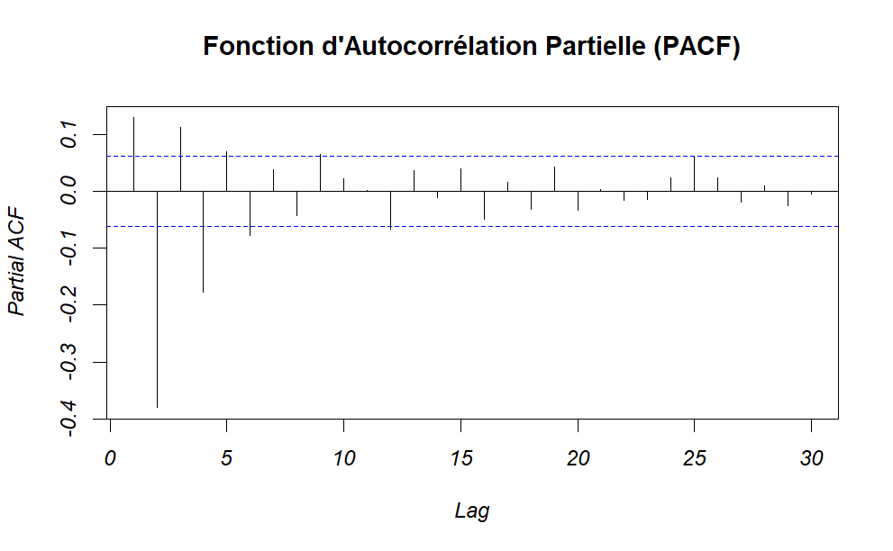

```r
# Tracer la fonction d'autocorrélation partielle (PACF)
pacf(Xt, main = "Fonction d'Autocorrélation Partielle (PACF)")
```

# $\textbf{2.3 Processus AR(p)}$

Nous souhaitons illustrer le comportement des fonctions d’autocorrélation et d’autocorrélation partielle pour les processus AR(p).

#### Processus AR(1)

Un processus AR(1) est défini par l’équation suivante :

$$X_t = \phi X_{t-1} + \varepsilon_t, \quad t \in \mathbb{N^*}$$

#### 4) Choix des paramètres

Nous choisissons $\phi = 0.7$.

##### Causalité

Le processus AR(1) est causal si la valeur absolue de $\phi$ est inférieure à 1, ce qui garantit que l’effet des valeurs passées de $X_t$ diminue exponentiellement dans le temps. Dans notre cas, avec $\phi = 0.7$, la condition de causalité est respectée, ce qui signifie que le processus est causal et stationnaire.

### Simulations et Tracés

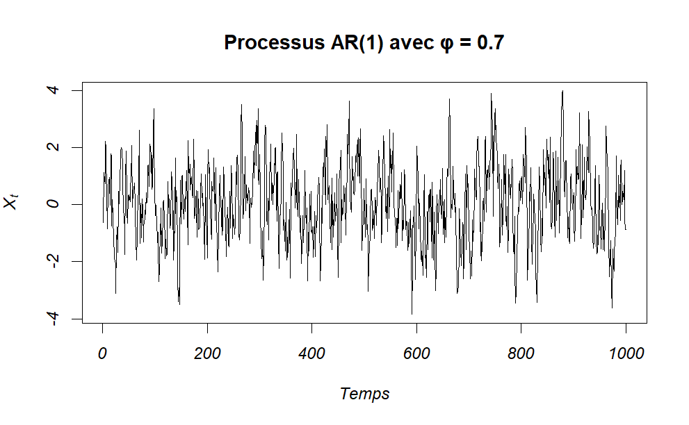

```r
# Paramètres
phi <- 0.7  # Coefficient AR(1)
n <- 1000   # Nombre d'observations

# Simuler un processus AR(1)
set.seed(123)  # Pour la reproductibilité
epsilon <- rnorm(n, mean = 0, sd = 1)  # Bruit blanc
Xt <- numeric(n)  # Initialisation du processus

# Boucle pour simuler le processus AR(1)
Xt[1] <- epsilon[1]  # Condition initiale
for (t in 2:n) {
  Xt[t] <- phi * Xt[t - 1] + epsilon[t]
}

# Tracer le processus simulé
ts.plot(Xt, main = "Processus AR(1) avec φ = 0.7", ylab = expression(X[t]), xlab = "Temps")
```

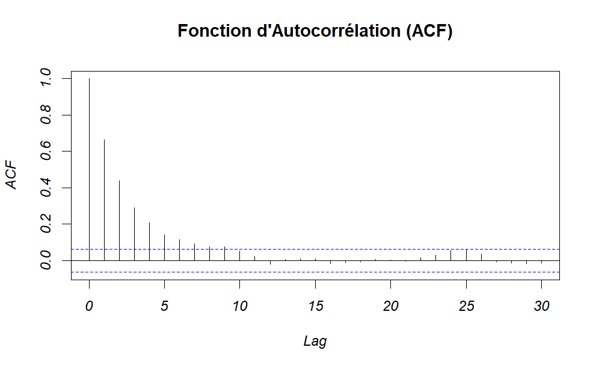

```r
# Tracer la fonction d'autocorrélation (ACF)
acf(Xt, main = "Fonction d'Autocorrélation (ACF)")
```

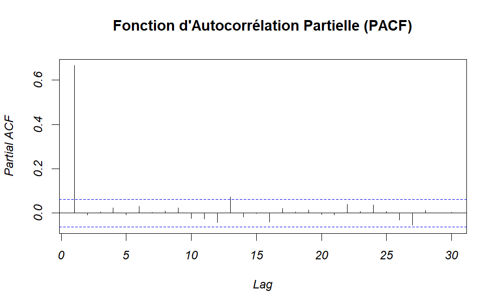

```r
# Tracer la fonction d'autocorrélation partielle (PACF)
pacf(Xt, main = "Fonction d'Autocorrélation Partielle (PACF)")
```

##### Comportements observés

- **ACF** : L’ACF montre une décroissance forte des valeurs d’autocorrélation avec l’augmentation des lags.
- **PACF** : La PACF coupe après le premier lag, indiquant une corrélation directe seulement entre $X_t$ et $X_{t-1}$.

##### Comparaison avec le comportement théorique

- **ACF théorique** : Dans le cas d’un AR(1) avec $\phi = 0.7$, nous nous attendons à ce que l’ACF décroisse exponentiellement à mesure que le lag augmente, conformément au modèle. Le comportement théorique est donc vérifié.
- **PACF théorique** : La PACF devrait montrer un seul pic significatif au premier lag, suivi de valeurs nulles, en raison de la nature d’un processus AR(1). Le comportement théorique est donc vérifié. Toutefois les valeurs suivantes proches de zéro mais non nulles s’expliquent par la représentation par l’estimateur empirique du PACF.

#### 5) Nous choisissons $\phi = -0.7$.

##### Causalité

Etant donné que le processus AR(1) est causal si la valeur absolue de $\phi$ est inférieure à 1, ce qui garantit que l’effet des valeurs passées de $X_t$ diminue exponentiellement dans le temps. Dans notre cas, avec $\phi = -0.7$, la condition de causalité est respectée, ce qui signifie que le processus est causal et stationnaire.

### Simulations et Tracés

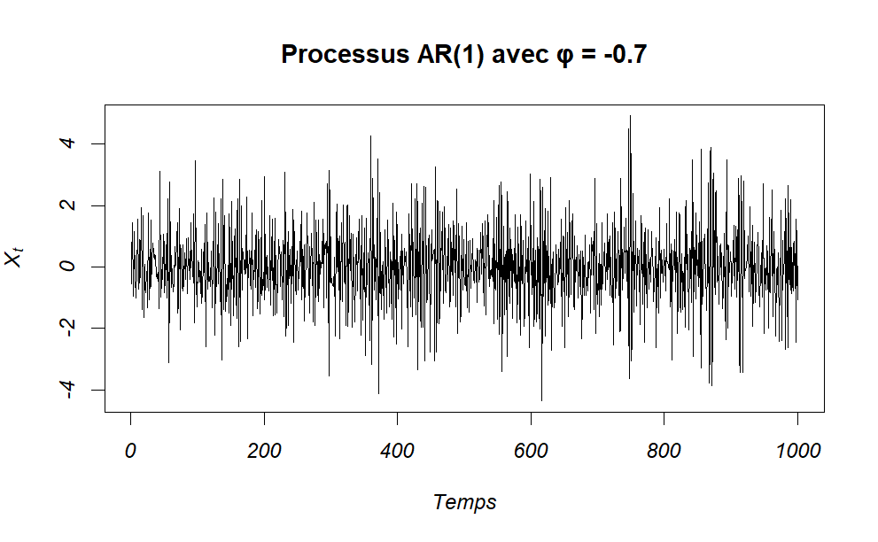

```r
# Paramètres
phi <- -0.7  # Coefficient AR(1)
n <- 1000   # Nombre d'observations

# Simuler un processus AR(1)
set.seed(123)  # Pour la reproductibilité
epsilon <- rnorm(n, mean = 0, sd = 1)  # Bruit blanc
Xt <- numeric(n)  # Initialisation du processus

# Boucle pour simuler le processus AR(1)
Xt[1] <- epsilon[1]  # Condition initiale
for (t in 2:n) {
  Xt[t] <- phi * Xt[t - 1] + epsilon[t]
}

# Tracer le processus simulé
ts.plot(Xt, main = "Processus AR(1) avec φ = -0.7", ylab = expression(X[t]), xlab = "Temps")
```

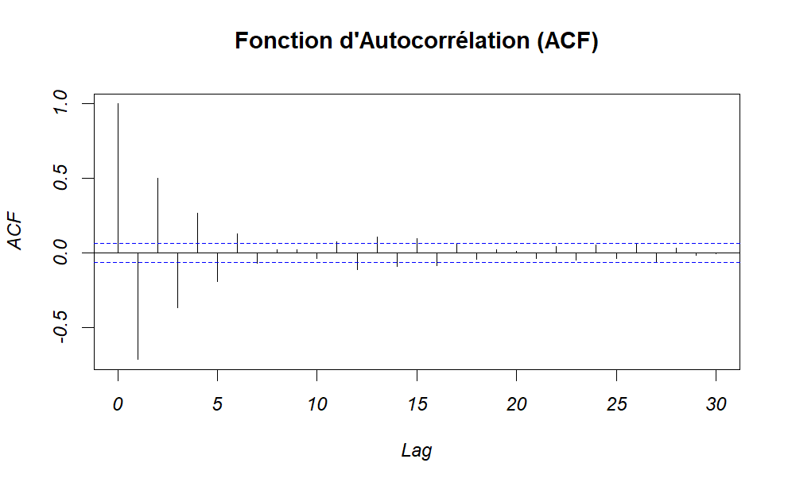

```r
# Tracer la fonction d'autocorrélation (ACF)
acf(Xt, main = "Fonction d'Autocorrélation (ACF)")
```

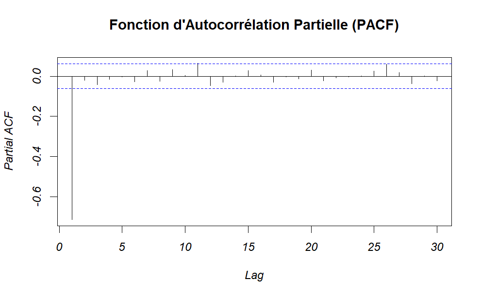

```r
# Tracer la fonction d'autocorrélation partielle (PACF)
pacf(Xt, main = "Fonction d'Autocorrélation Partielle (PACF)")
```

##### Comportements observés

- **ACF** : L’ACF montre une décroissance forte des valeurs d’autocorrélation avec l’augmentation des lags.
- **PACF** : La PACF coupe après le premier lag, indiquant une corrélation directe seulement entre $X_t$ et $X_{t-1}$.

##### Comparaison avec le comportement théorique

- **ACF théorique** : Dans le cas d’un AR(1) avec $\phi = -0.7$, nous nous attendons à ce que l’ACF décroisse exponentiellement à mesure que le lag augmente, conformément au modèle. Le comportement théorique est donc vérifié.
- **PACF théorique** : La PACF devrait montrer un seul pic significatif au premier lag, suivi de valeurs nulles, en raison de la nature d’un processus AR(1). Le comportement théorique est donc vérifié. Toutefois les valeurs suivantes proches de zéro mais non nulles s’expliquent par la représentation par l’estimateur empirique du PACF.

#### 6) Nous choisissons $\phi = 0.99$.

Dans cette question, nous analysons la stationnarité et la causalité d’un processus auto-régressif d’ordre 1 (AR(1)) avec $\phi = 0.99$, et nous observons ses caractéristiques pour $n = 200$ puis $n = 1000$.

#### Stationnarité et causalité

##### Stationnarité

Un processus AR(1) est stationnaire si $|\phi| < 1$. Avec $\phi = 0.99$, cette condition est respectée, ce qui signifie que le processus est stationnaire. Cependant, bien que le processus soit mathématiquement stationnaire, un coefficient $\phi$ proche de 1 implique une décroissance très lente de l’effet des valeurs passées, ce qui rend visuellement la série proche d’un processus non stationnaire.

##### Causalité

Pour la causalité, la condition est également $|\phi| < 1$. Avec $\phi = 0.99$, le processus est causal, car il est possible d’exprimer $X_t$ comme une somme pondérée des valeurs passées du bruit blanc $\varepsilon_t$ (effet décroissant très lentement en raison de $\phi$ proche de 1).

##### Simulation et visualisation

Nous allons simuler le processus avec $n = 200$ et $n = 1000$, puis observer l’évolution du processus dans le temps, ainsi que les fonctions d’autocorrélation (ACF) et d’autocorrélation partielle (PACF).

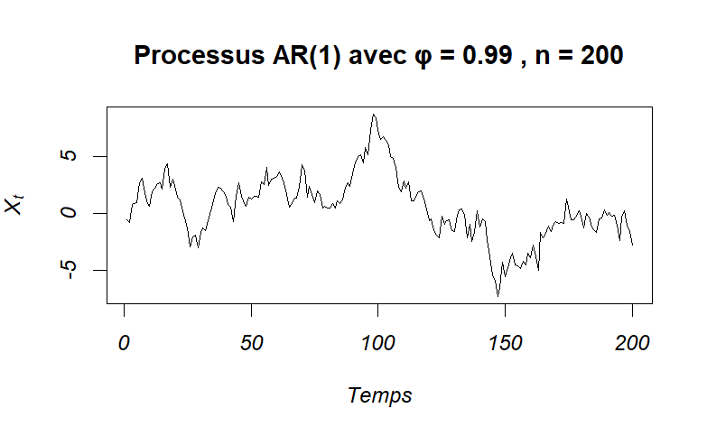

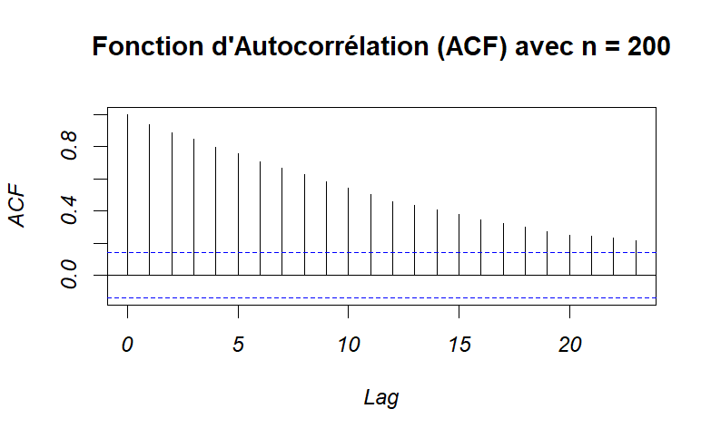

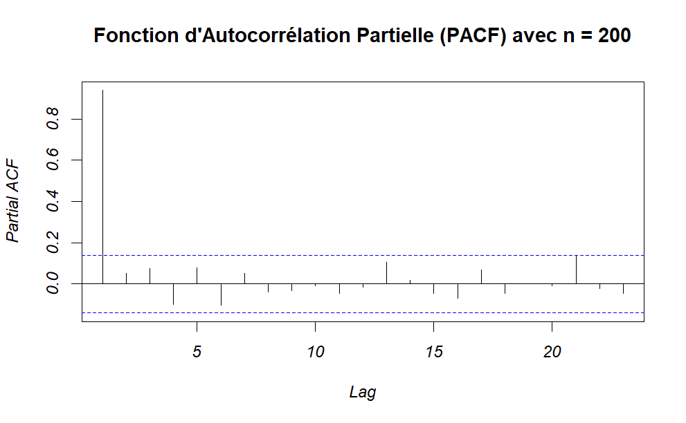

```r
# Paramètres
phi <- 0.99  # Coefficient AR(1)
n1 <- 200    # Nombre d'observations pour la première simulation
n2 <- 1000   # Nombre d'observations pour la deuxième simulation

# Fonction pour simuler le processus AR(1) et tracer les résultats
simulate_ar1 <- function(n, phi) {
  set.seed(123)  # Pour la reproductibilité
  epsilon <- rnorm(n, mean = 0, sd = 1)  # Bruit blanc
  Xt <- numeric(n)  # Initialisation du processus

  # Boucle pour simuler le processus AR(1)
  Xt[1] <- epsilon[1]  # Condition initiale
  for (t in 2:n) {
    Xt[t] <- phi * Xt[t - 1] + epsilon[t]
  }

  # Tracer le processus simulé
  ts.plot(Xt, main = paste("Processus AR(1) avec φ =", phi, ", n =", n),
          ylab = expression(X[t]), xlab = "Temps")

  # Tracer la fonction d'autocorrélation (ACF)
  acf(Xt, main = paste("Fonction d'Autocorrélation (ACF) avec n =", n))

  # Tracer la fonction d'autocorrélation partielle (PACF)
  pacf(Xt, main = paste("Fonction d'Autocorrélation Partielle (PACF) avec n =", n))
}

# Simulation avec n = 200
simulate_ar1(n1, phi)
```

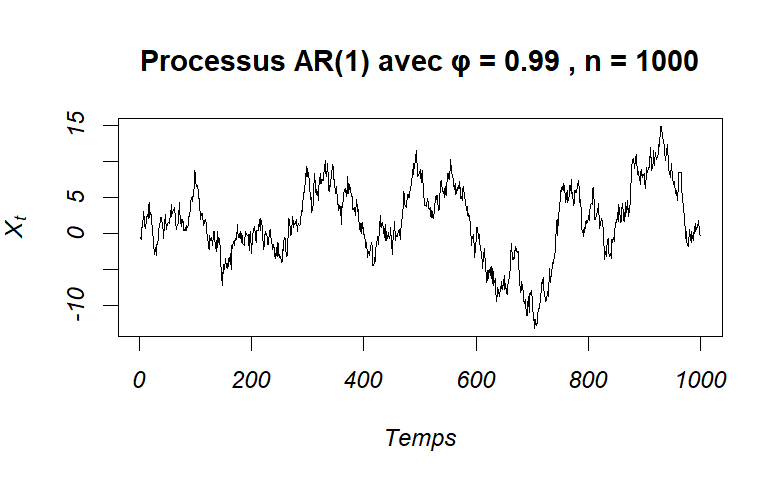

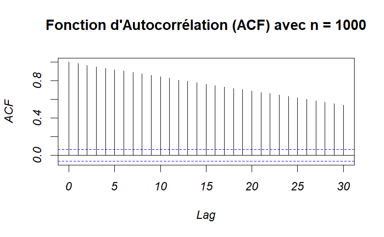

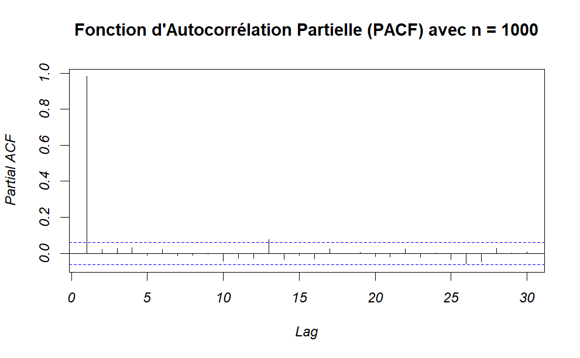

```r
# Simulation avec n = 1000
simulate_ar1(n2, phi)
```

##### Observations

1. **Stationnarité visuelle** : Bien que le processus soit mathématiquement stationnaire, le fait que $\phi = 0.99$ rend l’effet des valeurs passées très persistant. Cela donne une impression de “mémorisation” de long terme, ce qui peut visuellement ressembler à une série non stationnaire. Cette persistance est d’autant plus apparente avec $n = 1000$, où les variations lentes donnent l’impression que le processus pourrait être une marche aléatoire.
2. **ACF** : L’ACF décroît très lentement de manière exponentielle. Nous observons une autocorrélation significative sur de nombreux lags, ce qui traduit cette persistance des valeurs passées. Ce comportement est conforme au modèle théorique pour un processus AR(1) avec un coefficient proche de 1.
3. **PACF** : La PACF montre un pic important au premier lag, suivi de valeurs proches de zéro pour les lags suivants. Ce comportement est typique d’un processus AR(1), où seule la première autocorrélation partielle est significative.

#### Processus AR(2)

Un processus AR(2) est défini par l’équation suivante :

$$X_t = \phi_1 X_{t-1} + \phi_2 X_{t-2} + \varepsilon_t, \quad t \in
\mathbb{N^*}$$
#### 7-) Avec $\phi_1 = 1.2$ et $\phi_2 = -0.35$

Nous allons examiner la causalité de ce processus et simuler le processus pour analyser son comportement.

##### Vérification de la causalité

Pour que le processus AR(2) soit causal, les racines de l’équation caractéristique $1 - \phi_1 z - \phi_2 z^2 = 0$ doivent être en dehors du cercle unité. Cela implique que le module de chacune des racines doit être supérieur à 1.

##### Cherchons numériquement les racines avec R

```r
# Paramètres du processus AR(2)
phi1 <- 1.2
phi2 <- -0.35

# Calcul des racines de l'équation caractéristique
roots <- polyroot(c(1, -phi1, -phi2))

# Affichage des racines et de leurs modules
cat("Racines :", roots, "\n")
```

```
Racines : 1.428571+0i 2+0i
```

```r
cat("Modules des racines :", Mod(roots), "\n")
```

```
Modules des racines : 1.428571 2
```

Les modules des racines sont tous supérieurs à 1, alors le processus est causal.

##### Simulation du processus et tracés

On simule le processus pour $t = 1, \ldots, n$ avec $n = 1000$, puis on trace les fonctions d’autocorrélation (ACF) et d’autocorrélation partielle (PACF).

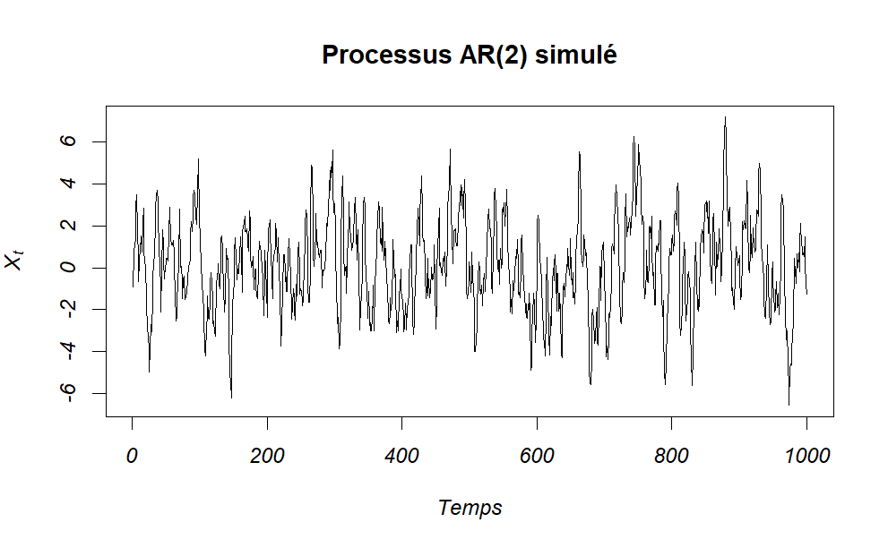

```r
set.seed(123)  # Pour la reproductibilité

# Paramètres et simulation du processus AR(2)
n <- 1000
epsilon <- rnorm(n)  # Bruit blanc
Xt <- numeric(n)

# Initialisation des deux premiers termes
Xt[1] <- epsilon[1]
Xt[2] <- phi1 * Xt[1] + epsilon[2]

# Boucle pour générer la série
for (t in 3:n) {
  Xt[t] <- phi1 * Xt[t - 1] + phi2 * Xt[t - 2] + epsilon[t]
}

# Tracé de la série simulée
plot(Xt, type = "l", main = "Processus AR(2) simulé", xlab = "Temps", ylab = expression(X[t]))
```

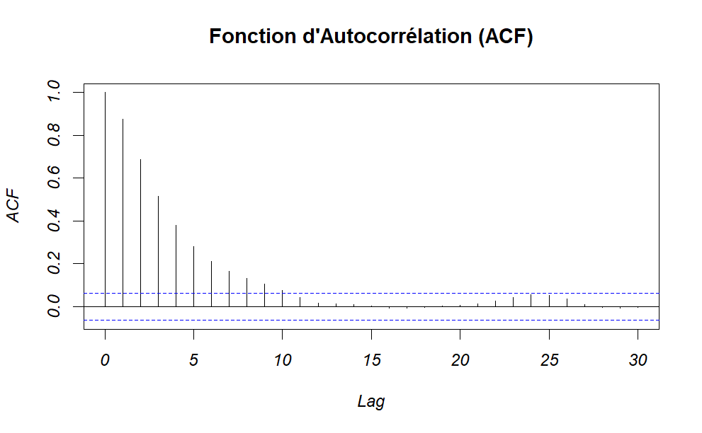

```r
# Tracé des fonctions d’autocorrélation et d’autocorrélation partielle
acf(Xt, main = "Fonction d'Autocorrélation (ACF)")
```

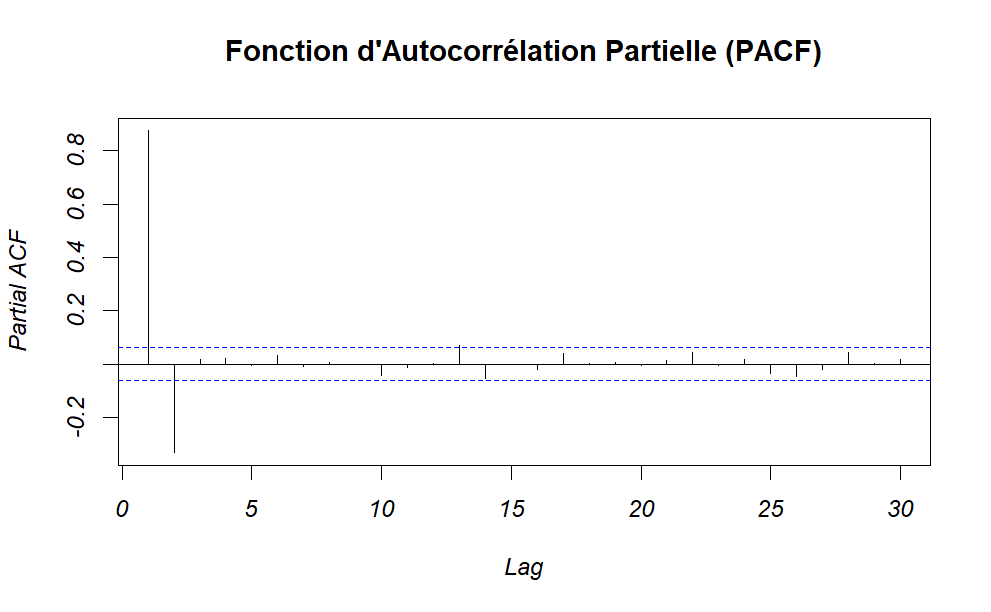

```r
pacf(Xt, main = "Fonction d'Autocorrélation Partielle (PACF)")
```

##### Calcul et Interprétation de la Fonction d’Autocovariance et de l’ACF

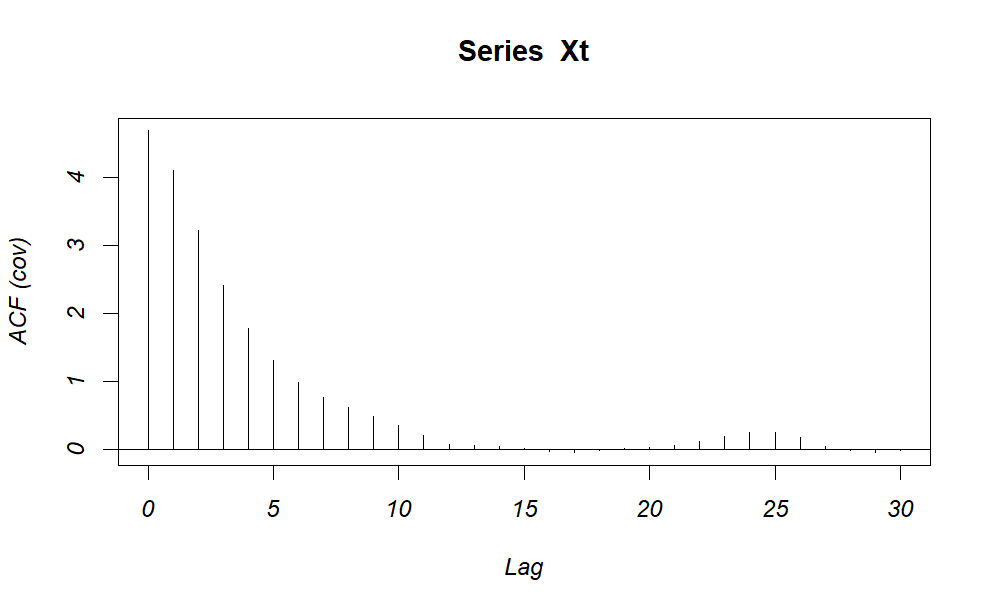

```r
# Fonction d’autocovariance empirique
gamma_hat <- acf(Xt, type = "covariance", plot = TRUE)$acf
```

```r
# Affichage de l’autocovariance et de l’autocorrélation empiriques
cat("Fonction d'autocovariance empirique (jusqu'au lag 10) :", gamma_hat[1:10], "\n")
```

```
Fonction d'autocovariance empirique (jusqu'au lag 10) : 4.688449 4.100015 3.220667 2.410325 1.781051 1.311519 0.9963597 0.7748723 0.6170317 0.4942759
```

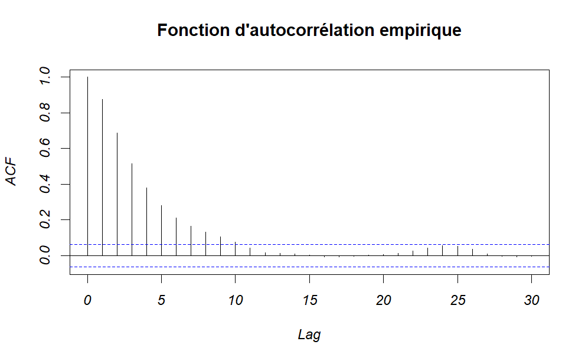

```r
acf(Xt, main = "Fonction d'autocorrélation empirique")
```

En comparant avec les résultats théoriques du cours, on peut conclure si l’autocorrélation suit bien les caractéristiques d’un processus AR(2) causal.

#### 8-) Avec $\phi_1 = 0.5$ et $\phi_2 = 0.24$

Nous allons examiner la causalité de ce processus et simuler le processus pour analyser son comportement.

##### Vérification de la causalité

Pour que le processus AR(2) soit causal, les racines de l’équation caractéristique $1 - \phi_1 z - \phi_2 z^2 = 0$ doivent être en dehors du cercle unité. Cela implique que le module de chacune des racines doit être supérieur à 1.

##### Cherchons numériquement les racines avec R

```r
# Paramètres du processus AR(2)
phi1 <- 0.5
phi2 <- 0.24

# Calcul des racines de l'équation caractéristique
roots <- polyroot(c(1, -phi1, -phi2))

# Affichage des racines et de leurs modules
cat("Racines :", roots, "\n")
```

```
Racines : 1.25+0i -3.333333+0i
```

```r
cat("Modules des racines :", Mod(roots), "\n")
```

```
Modules des racines : 1.25 3.333333
```

Les modules des racines sont tous supérieurs à 1, alors le processus est causal.

##### Simulation du processus et tracés

Nous simulons le processus pour $t = 1, \ldots, n$ avec $n = 1000$, puis nous traçons les fonctions d’autocorrélation (ACF) et d’autocorrélation partielle (PACF).

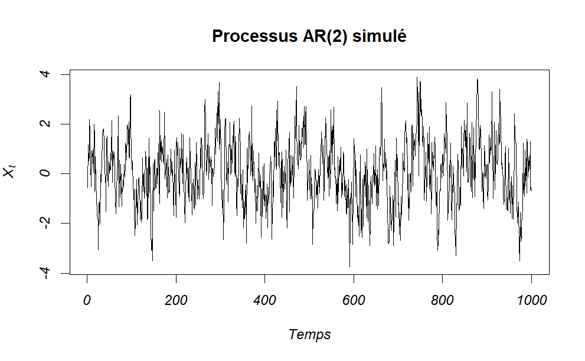

```r
set.seed(123)  # Pour la reproductibilité

# Paramètres et simulation du processus AR(2)
n <- 1000
epsilon <- rnorm(n)  # Bruit blanc
Xt <- numeric(n)

# Initialisation des deux premiers termes
Xt[1] <- epsilon[1]
Xt[2] <- phi1 * Xt[1] + epsilon[2]

# Boucle pour générer la série
for (t in 3:n) {
  Xt[t] <- phi1 * Xt[t - 1] + phi2 * Xt[t - 2] + epsilon[t]
}

# Tracé de la série simulée
plot(Xt, type = "l", main = "Processus AR(2) simulé", xlab = "Temps", ylab = expression(X[t]))
```

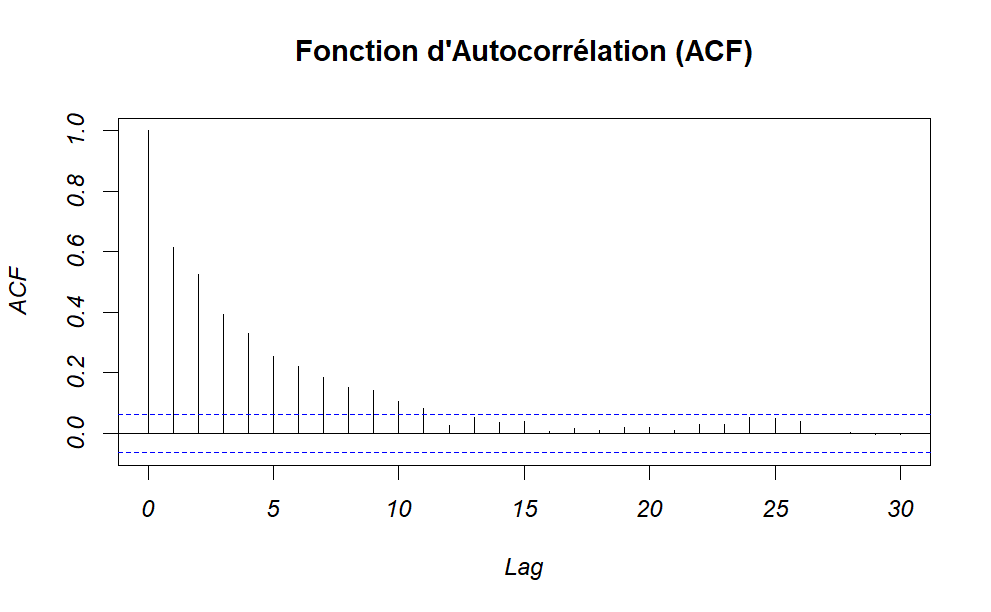

```r
# Tracé des fonctions d'autocorrélation et d'autocorrélation partielle
acf(Xt, main = "Fonction d'Autocorrélation (ACF)")
```

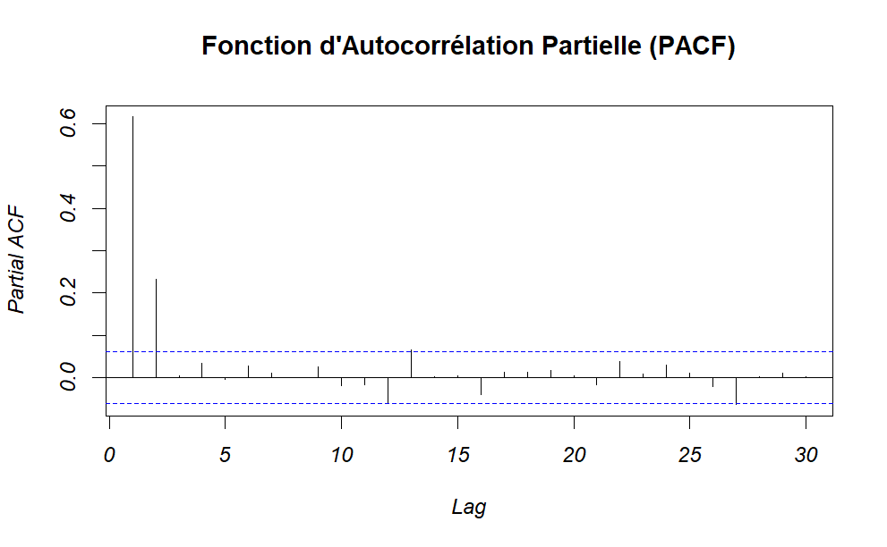

```r
pacf(Xt, main = "Fonction d'Autocorrélation Partielle (PACF)")
```

##### Comportements Observés

-**ACF** : L’ACF montre une décroissance progressive.

-**PACF** : La PACF montre des valeurs significatives pour les deux premiers lags, ce qui est caractéristique d’un processus AR(2), puis tend vers zéro.